# A very short introduction to python for social scientist

## Two Main Features of Python Relevant for Social scientists

### Python as a programming langauge

- Python is a programming language.
  - Think about programming languages in terms of natural languages.
  - Each language has a set of words and grammar rules that make communication between two people possible.
  - Programming languages are sets of rules and syntaxes (words) that make communication between humans and computers possible.

### Python is an object-oriented language.

- In Object-Oriented Programming (OOP), we keep data and the operations that can be performed on that data together in a so-called class
  - Imagine that you have a data point equal to 2.
    - Since 2 is an integer, you can perform all arithmetic operations on it.
    - Think of a class as a template where you can store your data.
    - Your data is 2, which we store in a variable with a specific name, and all arithmetic operations can be conducted on that variable.
    - Operations that you apply to a variable either come from Python's built-in functions or from external packages that you import.
- Every type in Python has methods (functions that perform operations) and attributes (properties or data associated with an instance).

### Python is modular.

- Python has a limited number of built-in functions. You can perform some tasks, but not everything.
- You need other sets of code that allow you to work with different types of data and perform different types of operations (functions).
  - These additional sets of code are organized into modules and packages.
- For almost every type of data and function, there is a package in Python that allows you to work with it.
  - You want to work with images: Pillow
  - You want to work with text: spaCy
  - You want to work with matrices: NumPy

```python
# Use 'import' to import a package into the Python environment
import pandas

# To use a method from an external package, you need to call the package first
df1 = pandas.DataFrame()

# Use an alias when importing a package to simplify method calls.
# The alias should be used thereafter to reference the package.
import pandas as pd
df1 = pd.DataFrame()

# Use 'from ... import ...' to import a specific method from a package.
# However, this is not recommended, as different packages may have methods with the same name but different behavior.
from pandas import DataFrame
df2 = DataFrame()
```

## Before everything starts

- Use '#' to add comments in your code
  - Commenting means that the computer reads the line but does not execute it.
    - It is used to explain what a piece of code does.
- Use the ymbol '=' to assign a value to a variable
  - x = 22
- Use double equal '==' to compare between two variables.
- Python is a case-sensitive language.
  - $ x \neq X$
- Indentation is important.
  - Improper indentation in your code will cause it to break.
- The basic syntax for output in Python is print().
- A variable is an instance of one of the types available in Python.

```python
# Use 'print()' as the basic output function in Python
# It is used to display the value of a variable or a message
print("This is ILE Summer School.")
```

```
This is ILE Summer School.
```

## Basic types of variables in python

- use '*type()*' to find out about a type of variable.

```python
# Assign an integer value to a variable
integer = 24

# Assign a floating-point value to a variable
float_value = 24.5

# Assign a string value to a variable
string = 'string'

# Assign a boolean value to a variable
boolean = True

# Use 'type()' to print the data type of each variable
print("integer: ", type(integer), "\n",
      "float: ", type(float_value), "\n",
      "string: ", type(string), "\n",
      "boolean: ", type(boolean))
```

```
integer:  <class 'int'>
 float:  <class 'float'>
 string:  <class 'str'>
 boolean:  <class 'bool'>
```

### Strings

- A string is a type that stores a series or sequence of characters.
- These characters can be letters, numbers, or symbols.

```python
a = 'This a letter.'

b = ' 1 2 3 4 5'

ab = 'This a string variable containing both character and numbers: 1 2 3 4'

print(type(a), type(b),type(ab))
```

```
<class 'str'> <class 'str'> <class 'str'>
```

```python
# Use '' or "" to assign a string value to a variable.
a = 'This is string with quation.'

b = "This is string with a dubble quation."

print("a: ", type(a), "\n",
      "b: ", type(b), "\n", )
```

```
a:  <class 'str'>
 b:  <class 'str'>
```

```python
# Use """ """ or ''' ''' for a strings with multiple lines.
longString = """
This is a longer string.
It has multiple lines.
It is very useful for NLP tasks.
             """

print(type(longString), "\n", longString)
```

```
<class 'str'>

This is a longer string.
It has multiple lines.
It is very useful for NLP tasks.
```

**Basic Operation on String variables**

```python
# Concatenation of string
string1 = "This is the first"
string2 = 'part of an string'
string3 = 'as an example of string concatentation.'
stringComplete = string1 + " " + string2 + " " + string3
print(stringComplete)
```

```
This is the first part of an string as an example of string concatentation.
```

```python
# Counting the number of words in a string has two steps

# Step 1: Split the string
# We need to choose a delimiter to split the string. In English (and other Latin-based languages), words are typically separated by whitespace
stringCompleteSplitted = stringComplete.split(' ')

# Step 2: Print the result of the split operation
print(stringCompleteSplitted)
```

```
['This', 'is', 'the', 'first', 'part', 'of', 'an', 'string', 'as', 'an', 'example', 'of', 'string', 'concatentation.']
```

```python
# Replace one part of a string with another part
string2Replace = "In mathematics the set of natural numbers starts with 1 and continues as 2, 3, ..."

# Use 'replace()' to substitute specific substrings with new values
stringReplaced = string2Replace.replace("1", "one").replace("2", "two").replace("3", "three")

# Print the updated string after replacements
print(stringReplaced)
```

```
In mathematics the set of natural numbers starts with one and continues as two, three, ...
```

**For more about strings and syntax for manipulating them:**

- Look at the tutorials on Regex

### Integer and Float

**The set of integer number is represented as integer type and the set of rational numbers is represented by float type.**

```python
numberInt = 4
numberFloat = 4.0
print(type(numberInt), type(numberFloat))
```

```
<class 'int'> <class 'float'>
```

**You can operates the basic arthmatic operations on both integer and float numbers.**

```python
# addition
number1 = 4
number2 = 8
addedNumber = number1 + number2
# multiplication
multipliedNumber = number1*number2
# division
dividedNumber = number2 / number1
# power
squaredNumber = number1**2
cubedNumber = number2**3
print("Addition: ", addedNumber, "\n",
     "multiplication: ", multipliedNumber, "\n",
     "Division: ", dividedNumber, "\n",
     "Squared number: ", squaredNumber, "\n",
     "Cubed Number: ", cubedNumber, "\n",)
```

```
Addition:  12
 multiplication:  32
 Division:  2.0
 Squared number:  16
 Cubed Number:  512
```

**For more arthmatic operations, use the following packages:**

- Numpy
  - Arthmatic operations
- Scipy
  - Statistical analysis
- Scympy
  - Symbolic math

### Boolean

**The boolean type may contain *True* or *False*.**

```python
primeNumber4 = False
firstPrimeNumber = True
```

### Conversion of one type to another type

```python
# You can convert numbers and floats to string variables.
number = 21
floatNumber = 21.21
numberString , floatNumberString = str(number), str(floatNumber)
print("number:", type(number), "\n",
     "floatNumber:", type(floatNumber), "\n",
     "numberString:", type(numberString), "\n",
     "floatNumberString:", type(floatNumberString))
```

```
number: <class 'int'>
 floatNumber: <class 'float'>
 numberString: <class 'str'>
 floatNumberString: <class 'str'>
```

```python
# You can convert strings containing numbers to integer.
numberString = "2"
floatString = "2.3"
numberInteger , floatNumberInteger = int(numberString), float(floatString)
print("number string:", type(numberString), "\n",
     "float string:", type(floatString), "\n",
     "numberInteger:", type(numberInteger), "\n",
     "floatNumberInteger:", type(floatNumberInteger))
```

```
number string: <class 'str'>
 float string: <class 'str'>
 numberInteger: <class 'int'>
 floatNumberInteger: <class 'float'>
```

```python
status = bool(input('OK to proceed: '))
```

```python
print(status)
print(type(status))
```

```
True
<class 'bool'>
```

## Basic types of collection types in python

- A collection is a signle object representing a group of objects. You can also call them containers.

### List

**Basic features of list**

- List is mutable. You can add or remove elements from a list.
- Elements are ordered in a list.
  - Elements in a list keep their order until its modified.
- A list can contain different types of elements.

**How to create a list**

```python
list1 = [2, 3, 5, 7, 11, 13, 17, 19, 23, 29, 31, 37, 2, 3, 5, 7, 11, 13, 17, 19, 23, 29, 31, 37, 2, 3, 5, 7, 11,2]
list1_word = list((
    "two", "three", "five", "seven", "eleven", "thirteen", "seventeen", "nineteen",
    "twenty-three", "twenty-nine", "thirty-one", "thirty-seven",
    "two", "three", "five", "seven", "eleven", "thirteen", "seventeen", "nineteen",
    "twenty-three", "twenty-nine", "thirty-one", "thirty-seven",
    "two", "three", "five", "seven", "eleven", "two"
))
listMixed = [2, 3, 5, 7, 11,"thirteen", "seventeen", "nineteen", "twenty-three"]
listPrimeShort = [2,3,5]
```

**How to amend a list**

```python
# You can use append to add ONE element
listPrimeShort.append(7)
print(listPrimeShort)
```

```
[2, 3, 5, 7]
```

```python
# You can use extend to add MORE THAN ONE elements.
listPrimeShort.extend([11, 13])
print(listPrimeShort)
```

```
[2, 3, 5, 7, 11, 13]
```

```python
# You can use insert(), if you want to insert an element in specific position.
listPrimeShort.insert(1, # first argument is the index of element
                      23 # second argument is the element itself
                     )
print(listPrimeShort)
```

```
[2, 23, 3, 5, 7, 11, 13]
```

**Operation on a list**

```python
# You can add to lists
list1 = [2, 3, 5, 7]
list2 = [11, 13, 17, 19]
list3 = list1 + list2
print(list3)
```

```
[2, 3, 5, 7, 11, 13, 17, 19]
```

### Tuple

**Basic features of tuple**

- Tuple is immutable.
  - This is the main difference between lists and tuples.
- Tuple is ordered. Every element has an index and can be called by its index.
- Elements can be repeated in tuples.
- We use comma (,) to separate elements in tuple.

**How to create a tuple**

- You can use *()* or *tuple()* to create tuple.

```python
# create a tuple with ()
tuple1 = (2, 3, 5, 7, 11, 13, 17, 19, 23, 29, 31, 37, 2, 3, 5, 7, 11, 13, 17, 19, 23, 29, 31, 37, 2, 3, 5, 7, 11,2)
# create a tuple using tuple()
tuple2 = tuple((43, 47, 53, 59, 61, 67, 71, 73, 79, 83, 89, 97))
```

```python
print(type(tuple1), "\n",
     type(tuple2))
```

```
<class 'tuple'>
 <class 'tuple'>
```

```python
tuple1_word = (
    "two", "three", "five", "seven", "eleven", "thirteen", "seventeen", "nineteen",
    "twenty-three", "twenty-nine", "thirty-one", "thirty-seven",
    "two", "three", "five", "seven", "eleven", "thirteen", "seventeen", "nineteen",
    "twenty-three", "twenty-nine", "thirty-one", "thirty-seven",
    "two", "three", "five", "seven", "eleven", "two"
)
```

**How to amend a tuple**

- The basic feature of tuple is to be immutable. Therefore, tuples cannot be amended.

**Operation on a tuple**

```python
# access the items through their index
print(tuple1_word[5])
```

```
thirteen
```

```python
# Find the index of an element
print(tuple1_word.index('eleven'))
```

```
4
```

```python
# count the number of items in a tuple
print(len(tuple1))
```

```
30
```

```python
# repretition of items in a tuple
print(tuple1.count(2))
```

```
4
```

### Set

**Basic features of set**

- Set is unordered (no index) and mutable container in python.
- **Set does not duplication.**
- Items cannot replace elements in a set.

**How to create a set**

```python
# Set can be defined by {}.
set1 = {2, 3, 5, 7, 11,}
# Set can be defined by set command:
set2 = set(["two", "three", "five", "seven", "eleven", "thirteen", "seventeen", "nineteen"])
```

**How to amend a set**

```python
# Use 'add()' to insert an element into a set
print(set1)
set1.add(13)
print(set1)
```

```
{2, 3, 5, 7, 11}
{2, 3, 5, 7, 11, 13}
```

```python
# Use 'update()' to add more than one element into a set
print(set1)
set1.update([17, 19])
print(set1)
```

```
{2, 3, 5, 7, 11, 13}
{17, 2, 3, 19, 5, 7, 11, 13}
```

```python
# Use 'remove()' or 'discard()' to remove an item from a set.
print(set1)
set1.remove(17)
print(set1)
set1.discard(19)
print(set1)
```

```
{17, 2, 3, 19, 5, 7, 11, 13}
{2, 3, 19, 5, 7, 11, 13}
{2, 3, 5, 7, 11, 13}
```

**Operation on a set**

```python
# Check existence of an element 'in' a set
if "two" in set2:
    print("The set has the element 'two'.")
else:
    print("No such element in set2")
```

```
The set has the element 'two'.
```

```python
# Check the length of a set
print(len(set1))
```

[output not shown]

```python
# Python has mathematical operation on sets as well:
set1 = {1,2,3,4,5}
set2 = {3,4,5,6,7}
set3 = {6,7,8,9,10}
# Use 'union()' to combine two sets. Remember that sets do not allow duplication.
print(set1.union(set2))
```

```
{1, 2, 3, 4, 5, 6, 7}
```

```python
# Use 'intersection' to find out about the shared elements between two sets
print(set1.intersection(set2), set1.intersection(set3))
```

```
{3, 4, 5} set()
```

```python
# use '-' to find out the elements exist in one set but does not exist in another set.
print(set1 - set2)
```

```
{1, 2}
```

### Dictionary

**Basic features of dictionary**

- Dictionary is a collection of keys and values that connected to each other.
- You can not have duplicated keys but you can have duplicated values.
- Dictionary is unordered, mutable and indexed.

**How to create a dictionary**

```python
# Use '{}' to create a dictionary
dict1 = {2:'two', 3:'three', 5:'five'}
# Use 'dict()' to create a dictionary
dict2 = dict([(7, 'seven'), (11, 'eleven'), (13, 'thirteen')])
print(dict1, "\n",
     dict2)
```

```
{2: 'two', 3: 'three', 5: 'five'}
 {7: 'seven', 11: 'eleven', 13: 'thirteen'}
```

```python
# Access each value by calling associated key
print(dict1[2])
```

```
two
```

```python
# Use 'get()' to access each value by calling associated key
dict1.get(3)
```

```
'three'
```

```python
# Use '{}' to create a dictionary
dict1 = {2:'two', 2:'three', 5:'five'}
```

**Keys and values can be any types.**

**How to amend a dictionary**

```python
# Add a key, value pairs by using '[]'
print(dict2)
dict2[19] = 'nineteen'
print(dict2)
```

```
{7: 'seven', 11: 'eleven', 13: 'thirteen'}
{7: 'seven', 11: 'eleven', 13: 'thirteen', 19: 'nineteen'}
```

```python
# Various ways to removing an item from a dictionary
## use 'pop.items()' to remove the last inserted key-value pair.
print(dict2)
dict2.popitem()
print(dict2)
# use 'pop()' to remove a key-value pair using key
dict2.pop(13)
print(dict2)
# use 'del' to remove a key-value pair using key
del dict2[11]
print(dict2)
# use 'clear()' to remove all key-value pairs in a dictionary
dict2 = dict([(7, 'seven'), (11, 'eleven'), (13, 'thirteen')])
print(dict2)
dict2.clear()
print(dict2)
```

```
{7: 'seven', 11: 'eleven', 13: 'thirteen', 19: 'nineteen'}
{7: 'seven', 11: 'eleven', 13: 'thirteen'}
{7: 'seven', 11: 'eleven'}
{7: 'seven'}
{7: 'seven', 11: 'eleven', 13: 'thirteen'}
{}
```

## Comparison - If statements

**If statements are used to compare one variable with another.**

```python
var1 = 3
var2 = 5
```

```python
if var1 > var2:
    print('Variable 1 is bigger than variable 2.')
elif var1 < var2:
    print('Variable 1 is smaller than variable 2.')
else:
    print('comparison unseccessful!')
```

```
Variable 1 is smaller than variable 2.
```

## Iteration

### For Loops

**You can use *for* loop to iteratre over collection types.**

```python
list1 = [2, 3, 5, 7]
tuple1 = (11, 13, 17, 19,)
set1 = set()
dict1 = {2:'two', 3:'three', 5:'five', 7:'seven', 11:'eleven'}
```

```python
for element in list1:
    newValue = element + 1
    print(newValue)
```

```
3
4
6
8
```

```python
for item in tuple1:
    newItem = item**3
    print(newItem)
```

```
1331
2197
4913
6859
```

```python
# iteration over dictionary can be over keys, over values or both:
## iteration over keys
for key in dict1.keys():
    print(key, key*2)
```

```
2 4
3 6
5 10
7 14
11 22
```

```python
## iteration over values
for value in dict1.values():
    newValue = value + ' number'
    print(newValue)
```

```
two number
three number
five number
seven number
eleven number
```

```python
## iteration over keys and values
for key, value in dict1.items():
    print(key*2, ': ', 'Squared root ' + value)
```

```
4 :  Squared root two
6 :  Squared root three
10 :  Squared root five
14 :  Squared root seven
22 :  Squared root eleven
```

### While Loops

**While loops are used to iterate as long as a condition is fulfilled**

```python
count = 0
print('Starting')
while count < 10:
    print(count, ' ', end='') # part of the while loop
    count += 1 # also part of the while loop
print('Done')
```

```
Starting
0  1  2  3  4  5  6  7  8  9  Done
```

## Introduction to Pandas package

### What is Pandas for?

- Pandas is the package for data wrangling and data manipulation in python.
- Originally Pandas were developed to handle time-series data. However, it covers almost all functionality requires for cross-sectional data manipulation as well.

### Basic types in Pandas

- Pandas has two types:
  - Series
    - One-dimensional data
  - Dataframe
    - More than one-dimensional data

**Data in Pandas types**

- You can import your data, almost in all formats, into pandas types.
  - To import excel sheets you need an extra package 'xlrd'. You just install it and pandas uses this package.
- You can also convert collection types into pandas types.

### Conversion of basic types to Pandas type

```python
# Pandas should be import before any of its method is called.
# Alias pd tradtionally used for Pandas
import pandas as pd
```

```python
# Conversion of a dictionary to Pandas's dataFrame
## keys are variable names and values are a list of ordered values.
data1 = {
    'Capital': ['Berlin', 'Tokyo', 'Canberra', 'Ottawa', 'Brasília'],
    'Country': ['Germany', 'Japan', 'Australia', 'Canada', 'Brazil'],
    'Estimated_Population_Millions': [3.6, 14.0, 0.4, 1.0, 3.1]
}

df1 = pd.DataFrame(data1)
df1
```

|  | Capital | Country | Estimated_Population_Millions |
| --- | --- | --- | --- |
| 0 | Berlin | Germany | 3.6 |
| 1 | Tokyo | Japan | 14.0 |
| 2 | Canberra | Australia | 0.4 |
| 3 | Ottawa | Canada | 1.0 |
| 4 | Brasília | Brazil | 3.1 |

```python
# Conversion of a dictionary to Pandas's dataFrame
# This a nested list and dictionary. The element in the list represents a row. Keys are name of variables and values are value for that specific row
data2 = [
    {'Capital': 'Berlin', 'Country': 'Germany', 'Estimated_Population_Millions': 3.6},
    {'Capital': 'Tokyo', 'Country': 'Japan', 'Estimated_Population_Millions': 14.0},
    {'Capital': 'Canberra', 'Country': 'Australia', 'Estimated_Population_Millions': 0.4},
    {'Capital': 'Ottawa', 'Country': 'Canada', 'Estimated_Population_Millions': 1.0},
    {'Capital': 'Brasília', 'Country': 'Brazil', 'Estimated_Population_Millions': 3.1}
]

df2 = pd.DataFrame(data2)
df2
```

|  | Capital | Country | Estimated_Population_Millions |
| --- | --- | --- | --- |
| 0 | Berlin | Germany | 3.6 |
| 1 | Tokyo | Japan | 14.0 |
| 2 | Canberra | Australia | 0.4 |
| 3 | Ottawa | Canada | 1.0 |
| 4 | Brasília | Brazil | 3.1 |

```python
# Conversion of a list to Pandas's dataFrame
# The list only includes values of each row for a set of variables.
# We need to pass on a separate this with names of variables.
data3 = [
    ['Berlin', 'Germany', 3.6],
    ['Tokyo', 'Japan', 14.0],
    ['Canberra', 'Australia', 0.4],
    ['Ottawa', 'Canada', 1.0],
    ['Brasília', 'Brazil', 3.1]
]

col1 = ['Capital', 'Country', 'Estimated_Population_Millions']

df3 = pd.DataFrame(data3, columns=col1)
df3
```

|  | Capital | Country | Estimated_Population_Millions |
| --- | --- | --- | --- |
| 0 | Berlin | Germany | 3.6 |
| 1 | Tokyo | Japan | 14.0 |
| 2 | Canberra | Australia | 0.4 |
| 3 | Ottawa | Canada | 1.0 |
| 4 | Brasília | Brazil | 3.1 |

### Importing dataset in Pandas dataframe

```python
# Use'read_excel' to read a dataset into pandas dataframe.
addressTip = "python_intro_data/tips.xlsx"
dfTips = pd.read_excel(addressTip)
```

### Some basic operations in pandas dataframe

```python
dfTips.head(5)
```

|  | total_bill | tip | sex | smoker | day | time | size |
| --- | --- | --- | --- | --- | --- | --- | --- |
| 0 | 16.99 | 1.01 | Female | No | Sun | Dinner | 2.0 |
| 1 | 10.34 | 1.66 | Male | No | Sun | Dinner | 3.0 |
| 2 | 21.01 | 3.50 | Male | No | Sun | Dinner | 3.0 |
| 3 | 23.68 | 3.31 | Male | No | Sun | Dinner | 2.0 |
| 4 | 24.59 | 3.61 | Female | No | Sun | Dinner | 4.0 |

```python
# descriptive statistics
dfTips.describe()
```

|  | total_bill | tip | size |
| --- | --- | --- | --- |
| count | 238.000000 | 242.000000 | 241.000000 |
| mean | 19.824832 | 3.004050 | 2.580913 |
| std | 8.957398 | 1.387629 | 0.950158 |
| min | 3.070000 | 1.000000 | 1.000000 |
| 25% | 13.302500 | 2.000000 | 2.000000 |
| 50% | 17.795000 | 2.960000 | 2.000000 |
| 75% | 24.075000 | 3.587500 | 3.000000 |
| max | 50.810000 | 10.000000 | 6.000000 |

```python
# Frequency in categorical variables
print(dfTips["day"].value_counts(), "\n",
      dfTips['time'].value_counts(normalize=True))
```

```
day
Sat     86
Sun     72
Thur    60
Fri     19
Name: count, dtype: int64
 time
Dinner    0.72314
Lunch     0.27686
Name: proportion, dtype: float64
```

```python
# selection of data
dfDinner = dfTips[dfTips['time'] == 'Dinner']
dfDinner
```

|  | total_bill | tip | sex | smoker | day | time | size |
| --- | --- | --- | --- | --- | --- | --- | --- |
| 0 | 16.99 | 1.01 | Female | No | Sun | Dinner | 2.0 |
| 1 | 10.34 | 1.66 | Male | No | Sun | Dinner | 3.0 |
| 2 | 21.01 | 3.50 | Male | No | Sun | Dinner | 3.0 |
| 3 | 23.68 | 3.31 | Male | No | Sun | Dinner | 2.0 |
| 4 | 24.59 | 3.61 | Female | No | Sun | Dinner | 4.0 |
| ... | ... | ... | ... | ... | ... | ... | ... |
| 239 | 29.03 | 5.92 | Male | No | Sat | Dinner | 3.0 |
| 240 | 27.18 | 2.00 | Female | Yes | Sat | Dinner | 2.0 |
| 241 | 22.67 | 2.00 | Male | Yes | Sat | Dinner | 2.0 |
| 242 | 17.82 | 1.75 | Male | No | Sat | Dinner | 2.0 |
| 243 | NaN | 3.00 | Female | No | Thur | Dinner | 2.0 |

175 rows × 7 columns

```python
# Check the missing value
dfDinner.isna().sum()
```

```
total_bill    3
tip           2
sex           2
smoker        3
day           5
time          0
size          2
dtype: int64
```

```python
# Use dropna to drop observations with a missing value
dfDinnerClean = dfDinner.dropna()
print(len(dfDinner), len(dfDinnerClean))
```

```
175 159
```

```python
# Use argument subset to drop observations that have missing values for a certain variables.
dfDinnerClean1 = dfDinner.dropna(subset=['total_bill', 'tip'])
print(len(dfDinner), len(dfDinnerClean1), len(dfDinnerClean))
```

```
175 170 159
```

```python
# Use 'fillna()' to fill out the missing values with a specific value
dfDinnerFilled = dfDinner.fillna(value=0, axis=1)
dfDinnerFilled.isna().sum()
```

```
total_bill    0
tip           0
sex           0
smoker        0
day           0
time          0
size          0
dtype: int64
```

```python
# Fill out a specific column
## make a copy of the dataset
dfDinnerFilledTip = dfDinner.copy()
## replace the column that you want to fill out in the new dataset with a one that you fill out
dfDinnerFilledTip['total_bill'] = dfDinner['total_bill'].fillna(0)
dfDinnerFilledTip.isna().sum()
```

```
total_bill    0
tip           2
sex           2
smoker        3
day           5
time          0
size          2
dtype: int64
```

```python
# Use 'groupby()' command to do calculation at a group level
dfSomker = dfTips.groupby('smoker')[['tip','total_bill']].mean()
dfSomker
```

| smoker | tip | total_bill |
| --- | --- | --- |
| No | 2.991854 | 19.188278 |
| Yes | 3.008710 | 20.756344 |

## Introduction to Seaborn - Matplotlib

- Matplotlib is the basic for data visualization in python.
- Seaborn, another visalization package, is developed on basis of matplotlib. It is much easier to use and figures produced by seaborn look better.
  - That means that you need to import matplotlib to be able to use seaborn.

```python
import matplotlib.pyplot as plt
import seaborn as sns
```

### Single variable

**Continuous Variable**

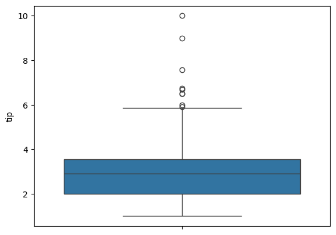

```python
# Boxplot
sns.boxplot(y='tip',
           data=dfTips)
```

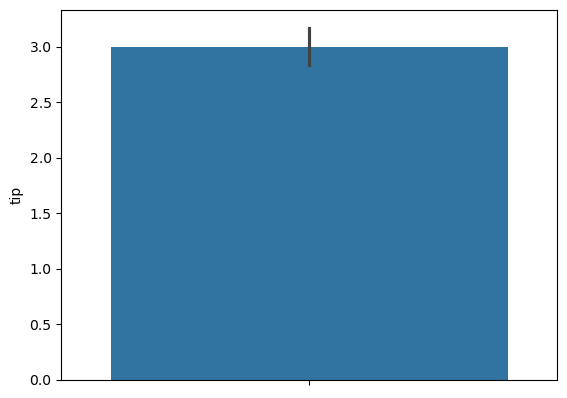

```python
# Boxplot
sns.barplot(y='tip',
           data=dfTips)
```

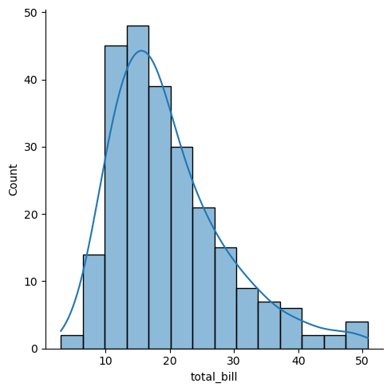

```python
sns.displot(data=dfTips, x="total_bill", kde=True)
```

**Categorical variable**

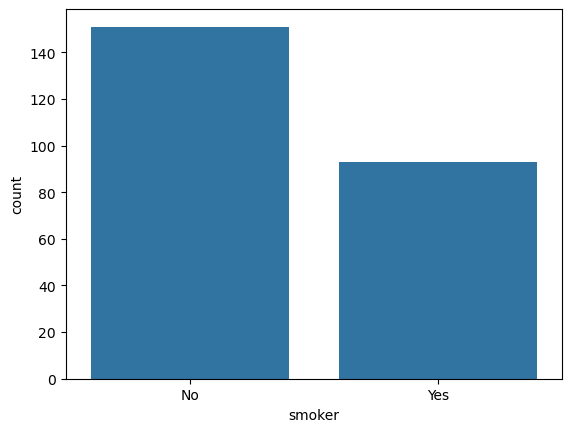

```python
# Use 'countplot()' plot a categorical variable
sns.countplot(data=dfTips, x="smoker")
```

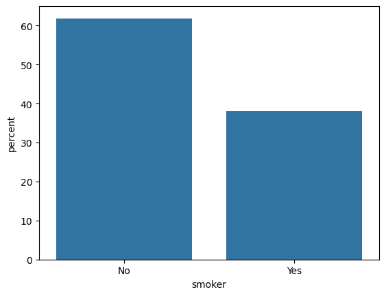

```python
# Use argument 'stat' to plot percentage or probability of a category
sns.countplot(data=dfTips, x="smoker", stat='percent')
```

### Two variables

**Continious versus continuous variables**

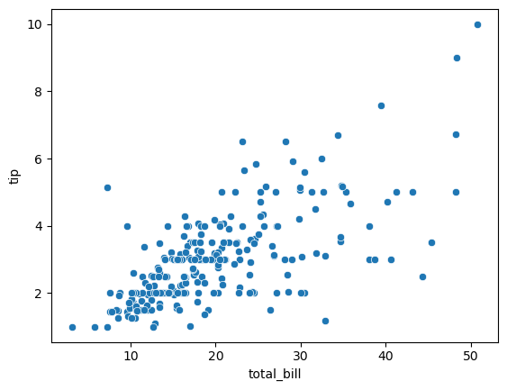

```python
# Use 'scatterplot()' to plot two continuous variable against each other
sns.scatterplot(data=dfTips, x="total_bill", y="tip")
```

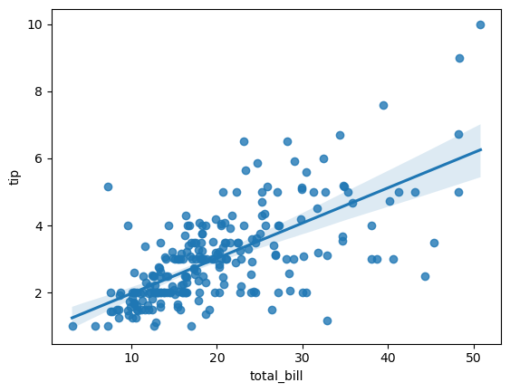

```python
# Use 'lmplot()' or 'regplot' to create a regression plot
sns.regplot(data=dfTips, x="total_bill", y="tip")
```

**continuous versus categorical variables**

```python
dfTips
```

|  | total_bill | tip | sex | smoker | day | time | size |
| --- | --- | --- | --- | --- | --- | --- | --- |
| 0 | 16.99 | 1.01 | Female | No | Sun | Dinner | 2 |
| 1 | 10.34 | 1.66 | Male | No | Sun | Dinner | 3 |
| 2 | 21.01 | 3.50 | Male | No | Sun | Dinner | 3 |
| 3 | 23.68 | 3.31 | Male | No | Sun | Dinner | 2 |
| 4 | 24.59 | 3.61 | Female | No | Sun | Dinner | 4 |
| ... | ... | ... | ... | ... | ... | ... | ... |
| 239 | 29.03 | 5.92 | Male | No | Sat | Dinner | 3 |
| 240 | 27.18 | 2.00 | Female | Yes | Sat | Dinner | 2 |
| 241 | 22.67 | 2.00 | Male | Yes | Sat | Dinner | 2 |
| 242 | 17.82 | 1.75 | Male | No | Sat | Dinner | 2 |
| 243 | 18.78 | 3.00 | Female | No | Thur | Dinner | 2 |

244 rows × 7 columns

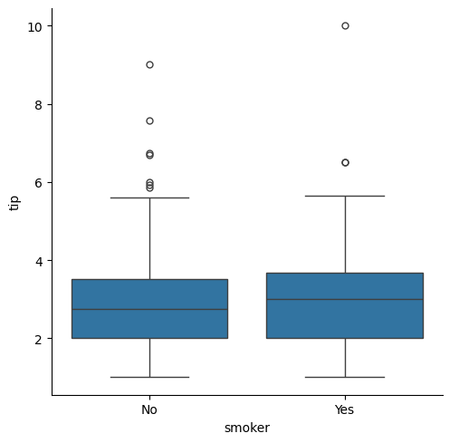

```python
# use 'catplot()' to plot a continuous variable against categorical variable
sns.catplot(data=dfTips, x="smoker", y="tip", kind="box")
```

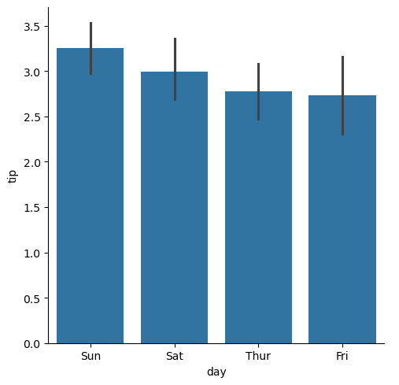

```python
# use the argument 'kind' to change the type of plot you
sns.catplot(data=dfTips, x="day", y="tip", kind="bar")
```

**Categorical Variables versus categorical variables**

- To use *catplot()* for two categorical variables, we have to group our variables of interest

```python
dfTipsGrouped1 = dfTips.groupby(['sex'])['day'].value_counts().reset_index()
dfTipsGrouped1
```

|  | sex | day | count |
| --- | --- | --- | --- |
| 0 | Female | Thur | 32 |
| 1 | Female | Sat | 28 |
| 2 | Female | Sun | 18 |
| 3 | Female | Fri | 9 |
| 4 | Male | Sat | 59 |
| 5 | Male | Sun | 58 |
| 6 | Male | Thur | 30 |
| 7 | Male | Fri | 10 |

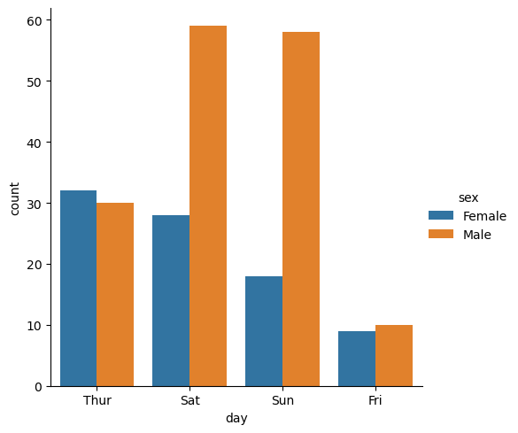

```python
# use the argument 'kind' to change the type of plot you
sns.catplot(data=dfTipsGrouped1, x="day", y="count", hue='sex', kind="bar")
```

## Other useful packages in python for computational social science

- **Data Visulization**
  - Static
    - Seaborn
  - Dynamic
    - Plotly
- **Numerical analysis**
  - Numpy
- **Statistical Analysis**
  - Scipy
- **Econometrics**
  - Statsmodels

# Some references for learning python more in depth

- Introduction
  - Hunt (2019), A Beginners Guide to Python 3 Programming
- Data Science
  - McKinney (2014), python for data science

# Some YouTube tutorial for learning python

- https://www.youtube.com/watch?v=_uQrJ0TkZlc&t=109s
- https://www.youtube.com/watch?v=YYXdXT2l-Gg&list=PL-osiE80TeTskrapNbzXhwoFUiLCjGgY7